# Workbook_V3

Copy, paste and run the `polygon` function below. Then write a Python code to call the function with the given data.

```python
def polygon(x,n):
  import matplotlib.pyplot as plt
  import numpy as np

  freq, bins, edges = plt.hist(x,bins=n,ec="k",range=[min(x),max(x)+1])
  plt.title("Polygon")
  plt.xlabel('data values')
  plt.ylabel('frequency')

  a1=bins[0]-(bins[1]-bins[0])
  a2=bins[-1]+(bins[1]-bins[0])
  bin1=np.insert(bins,[0],a1)
  bin1=np.append(bin1,a2)

  freq,edges,_=plt.hist(x,bins=bin1,ec='k', range=[min(x),max(x)+1])
  midpoints=0.5*(edges[1:]+edges[:-1])
  plt.plot(midpoints,freq)
  plt.xticks(bin1)
  plt.show()
```

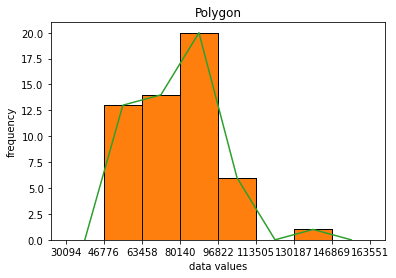

```python
x = [46776, 53736, 53736, 54840, 57408, 57408, 57408, 57408, 57408, 57408,
     60108, 60108, 62712, 63552, 66852, 66852, 69732, 70032, 70044, 70272,
     72024, 73380, 73380, 73380, 75408, 75468, 76248, 80484, 80484, 80484,
     82476, 82788, 82836, 83676, 84324, 84324, 84324, 85848, 87564, 88272,
     88272, 90828, 92004, 92304, 92520, 96060, 96096, 100680, 100716, 100716,
     103764, 105420, 109620, 146868]

polygon(x,6)
```

**Lab 5.4.4**

Copy the 'ogive' function, paste and run it below. Then use it to make an ogive.

```python
def ogive(x,n):
  import matplotlib.pyplot as plt
  import numpy as np

  freq, bins, edges = plt.hist(x,bins=n,ec="k",range=[min(x),max(x)+1])
  plt.title("Ogive")
  plt.xlabel('data values')
  plt.ylabel('Cumulative frequency')

  a1=bins[0]-(bins[1]-bins[0])
  a2=bins[-1]+(bins[1]-bins[0])
  bin1=np.insert(bins,[0],a1)
  bin1=np.append(bin1,a2)

  freq,edges,_=plt.hist(x,bins=bin1,ec='k', range=[min(x),max(x)+1])

  ogive1 = edges[:-1]
  cumfreq = np.cumsum(freq)
  plt.plot(ogive1,cumfreq)
  plt.xticks(bin1)
  plt.show()
```

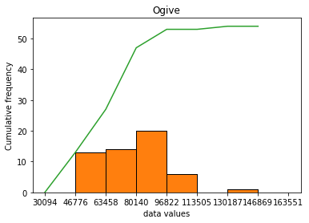

```python
x = [46776, 53736, 53736, 54840, 57408, 57408, 57408, 57408, 57408, 57408,
     60108, 60108, 62712, 63552, 66852, 66852, 69732, 70032, 70044, 70272,
     72024, 73380, 73380, 73380, 75408, 75468, 76248, 80484, 80484, 80484,
     82476, 82788, 82836, 83676, 84324, 84324, 84324, 85848, 87564, 88272,
     88272, 90828, 92004, 92304, 92520, 96060, 96096, 100680, 100716, 100716,
     103764, 105420, 109620, 146868]

ogive(x,6)
```

**Lab 5.5.1**

Copy the `dotplots` function and paste it below. Then use it to draw a dot plot.

```python
# dotplot by Patrick FitzGerald
def dotplots(x,x_label="Data Values"):   # function name is dotplots takes a x

 import numpy as np
 import matplotlib.pyplot as plt

 data = np.array(x)   # convert to array
 values, counts = np.unique(data, return_counts=True)

# dot plot with appropriate figure size and y-axis limits
 fig, ax = plt.subplots(figsize=(6, 2.25))
 for value, count in zip(values, counts):
    ax.plot([value]*count, list(range(count)), 'co', ms=10, linestyle='')
 for spine in ['top', 'right', 'left']:
    ax.spines[spine].set_visible(False)
 ax.yaxis.set_visible(False)
 ax.set_ylim(-1, max(counts))
 ax.set_xticks(range(min(values), max(values)+1))
 ax.tick_params(axis='x', length=0, pad=8, labelsize=12)

 plt.suptitle("Dot Plot")
 plt.ylabel("frequency")
 plt.xlabel(x_label)

 return plt.show()
```

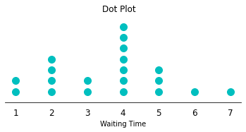

```python
x = [6, 4, 4, 2, 1, 3, 5, 2, 4, 2, 5, 4, 4, 7, 4, 3, 4, 1, 2, 5]
dotplots(x, "Waiting Time")
```

**Lab 5.6.1**

First install stemgraphic

```python
pip install stemgraphic
```

```
(<Figure size 540x216 with 1 Axes>,
```

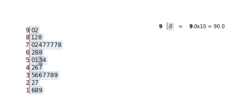

```python
import stemgraphic

x = [54, 22, 77, 92, 51, 68, 37, 27, 68, 47, 42, 38, 18, 46, 74, 77, 81, 78, 16,
     35, 77, 90, 82, 36, 50, 39, 19, 62, 70, 88, 36, 37, 53, 72, 77]
stemgraphic.stem_graphic(x,scale=10,aggregation=False)
```

**Lab 6.1.1**

```python
import numpy as np

x = [46776, 53736, 53736, 54840, 57408, 57408, 57408, 57408, 57408, 57408,
     60108, 60108, 62712, 63552, 66852, 66852, 69732, 70032, 70044, 70272,
     72024, 73380, 73380, 73380, 75408, 75468, 76248, 80484, 80484, 80484,
     82476, 82788, 82836, 83676, 84324, 84324, 84324, 85848, 87564, 88272,
     88272, 90828, 92004, 92304, 92520, 96060, 96096, 100680, 100716, 100716,
     103764, 105420, 109620, 146868]


print("mean and median")
print(np.mean(x))
print(np.median(x))
```

```
mean and median
78460.0
78366.0
```

Interpretation: The mean and median are 78460.0 and 78366.0 respectively.

**Lab 6.2.1**

```python
import numpy as np

x=[75408, 82368, 103968, 82368, 42996, 85992, 67464, 103716, 134292, 113484,
   94848, 101628, 119712, 61776, 122496, 57720, 119712, 119712, 61140, 103716,
   67464, 58680, 91020, 83268, 62712, 78828, 82788, 91020, 75408, 59820, 79812,
   63348, 122496, 72744, 98628, 103968, 103968, 131664, 115788, 76248, 119712,
   83268, 75408, 75408, 95172, 67824, 75408, 119712, 141696, 97392, 83268,
   59820, 97668, 82368, 53736, 65676, 103716, 94848, 79020, 67824, 86856,
   103716, 75408, 119712, 91944, 94848, 66336, 99480, 119712]

print('the population variance and standared devaition are')
print(np.var(x,ddof=0))
print(np.std(x,ddof=0))
```

```
the population variance and standared devaition are
490101843.4177693
22138.24390998006
```

**Lab 6.2.2**

```python
import numpy as np

x = [46776, 53736, 53736, 54840, 57408, 57408, 57408, 57408, 57408, 57408,
     60108, 60108, 62712, 63552, 66852, 66852, 69732, 70032, 70044, 70272,
     72024, 73380, 73380, 73380, 75408, 75468, 76248, 80484, 80484, 80484,
     82476, 82788, 82836, 83676, 84324, 84324, 84324, 85848, 87564, 88272,
     88272, 90828, 92004, 92304, 92520, 96060, 96096, 100680, 100716, 100716,
     103764, 105420, 109620, 146868]

print('The sample variance and standard deviation')
print(np.var(x,ddof=1))
print(np.std(x,ddof=1))
```

```
The sample variance and standard deviation
333192547.0188679
18253.562584297564
```

Interpretation: The sample variance and standard devation are 333192547.0188679 and 18253.562584297564 respectively.

**Lab 6.4.3**

```python
import numpy as np

x = [5200, 7200, 9200, 11200, 13500]
f = [9,21,18,16,5]

np.average(x,weights=f)
```

```
8844.927536231884
```

Interpretaton: The sample mean is 8844.927536231884

```python
import numpy as np

x = [5200, 7200, 9200, 11200, 13500]
f = [9,21,18,16,5]

np.sqrt(np.cov(x,fweights=f,ddof=1))
```

```
2350.6905263250064
```

Interpretation: The sample standard devition 2350.6905263250064

**Lab 7.1.1**

```python
import numpy as np

x = [75408, 82368, 103968, 82368, 42996, 85992, 67464, 103716, 134292, 113484,
     94848, 101628, 119712, 61776, 122496, 57720, 119712, 119712, 61140, 103716,
     67464, 58680, 91020, 83268, 62712, 78828, 82788, 91020, 75408, 59820,
     79812, 63348, 122496, 72744, 98628, 103968, 103968, 131664, 115788, 76248,
     119712, 83268, 75408, 75408, 95172, 67824, 75408, 119712, 141696, 97392,
     83268, 59820, 97668, 82368, 53736, 65676, 103716, 94848, 79020, 67824,
     86856, 103716, 75408, 119712, 91944, 94848, 66336, 99480, 119712]

np.quantile(x,[.10,.25,.50,.75,.90])
```

```
array([ 61648.8,  75408. ,  85992. , 103716. , 119712. ])
```

Interpretation: The 10th, 25th, 50th, 75th and 90th percentile are 61648.8, 75408.0, 85992.0, 103716.0, and 119712.0 respectively.

**Lab 7.2.1**

```python
import numpy as np
from scipy import stats

x = [46776, 53736, 53736, 54840, 57408, 57408, 57408, 57408, 57408, 57408,
       60108, 60108, 62712, 63552, 66852, 66852, 69732, 70032, 70044, 70272,
       72024, 73380, 73380, 73380, 75408, 75468, 76248, 80484, 80484, 80484,
       82476, 82788, 82836, 83676, 84324, 84324, 84324, 85848, 87564, 88272,
       88272, 90828, 92004, 92304, 92520, 96060, 96096, 100680, 100716, 100716,
       103764, 105420, 109620, 146868]

x_array = np.array(x)   # convert the list to a numpy array

stats.percentileofscore(x_array,80000,kind='rank')
```

```
50.0
```

Interpretation: The percentile salary rank of an emplyee with salary 80000 is 50.

**Lab 7.3.1**

```
{'boxes': [<matplotlib.lines.Line2D at 0x7fdd00f4be90>],
 'caps': [<matplotlib.lines.Line2D at 0x7fdd00ed1f10>,
 'fliers': [<matplotlib.lines.Line2D at 0x7fdd00ede490>],
 'means': [<matplotlib.lines.Line2D at 0x7fdd00ed7f50>],
 'medians': [<matplotlib.lines.Line2D at 0x7fdd00ed7a10>],
 'whiskers': [<matplotlib.lines.Line2D at 0x7fdd00ed1490>,
```

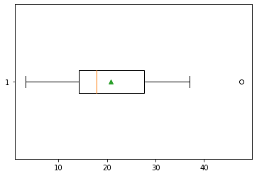

```python
import matplotlib.pyplot as plt
x = [27.3, 5.5, 14.3, 3.2, 16.8, 17.9, 14.2, 14.2, 9.6, 34.7, 8.9, 30.1,
        27.7, 17.7, 21.8, 47.7, 37, 24.9]
plt.boxplot(x,vert=False,showmeans=True)
```

**Lab 8.1.1**

```python
import numpy as np

x = [0, 1, 2, 3, 4, 5, 6, 7, 8]
p = [0.197, 0.212, 0.255,	0.182, 0.09, 0.04, 0.02, 0.003, 0.001]

average = np.average(x, weights=p)
std = np.sqrt(np.cov(x,aweights=p, ddof=0))

print('mean is',average)
print('standard deviation is',std)
```

```
mean is 1.977
standard deviation is 1.5272429407268509
```

**Lab 8.2.1**

```python
from scipy import stats
stats.binom.pmf(1,30,.21)
```

```
0.006769026228180294
```

```python
from scipy import stats
stats.binom.cdf(4,30,.21)
```

```
0.2145879371696642
```

```python
from scipy import stats
1-stats.binom.cdf(3,30,.21)
```

```
0.9015599620024068
```

Interpretation:

$P(x=1)$ = 0.006769026228180294

$P(x \le 4)$ = 0.2145879371696642

**Lab 8.2.2**

```python
# binomial graph with n and p
def binomplot(n,p):
  from scipy import stats
  import numpy as np
  import matplotlib.pyplot as plt

  x = np.arange(0,n+1)
  y = stats.binom.pmf(x,n,p)
  plt.bar(x,y,width=0.2)

  plt.suptitle("Binomial Plot")
  plt.xlabel("x values")
  plt.ylabel("probability")

  return plt.show()
```

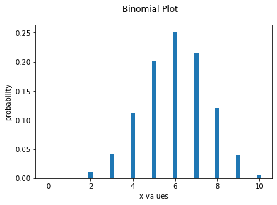

```python
binomplot(10,0.6)
```

**Lab 9.1.1**

```python
from scipy import stats
stats.uniform.cdf(15,5,15-5)
```

```
1.0
```

**Lab 9.2.1**

```python
from scipy import stats
stats.norm.cdf(1.5,0,1)
```

```
0.9331927987311419
```

**Lab 9.2.2**

```python
from scipy import stats
stats.norm.cdf(27726,27191,7126)
```

```
0.5299233487082249
```

Interpretation: Probability that the average cost is less than `$27726` is 0.5299233487082249

$P(X<27726)=0.5299233487082249$

**Lab 9.2.3**

```python
from scipy import stats
stats.norm.ppf(.75,27191,7126)
```

```
31997.413959897276
```

Interpretation: 75 percent of the average college costs are less than or equal to 31997.413959897276

**Lab 9.3.1**

```python
from scipy import stats
stats.norm.cdf(6,5,1/(10**.5))
```

```
0.9992172988709987
```

Interpretation: The probabilty that the mean length is less than 6 is 0.9992172988709987. That is $P(\bar{x}<6)=0.9992172988709987$

```python
from scipy import stats
stats.norm.cdf(6,5,1/(10**.5)) - stats.norm.cdf(5,5,1/(10**.5))
```

```
0.49921729887099875
```

Interpretation: The probability that the average length is between 5 and 6 is 0.49921729887099875. That is, $P(5<\bar{x}<6)=0.49921729887099875$

**Lab 10.1.1**

```python
# Confidence interval, given confidence level C, std, n
def conf_z_mean(C,mean,std,n):
     from scipy import stats
     ebm = (std/n**.5)*stats.norm.ppf(C+(1-C)/2,0,1)
     return print("(", mean-ebm, ",", mean+ebm, ')')
```

```python
conf_z_mean(.90,80,15,50)
```

```
( 76.51073853896997 , 83.48926146103003 )
```

**Lab 10.2.1**

```python
# marigin of error given the level of confidence C, mean, std and n
def error_t_mean(C,std,n):
    from scipy import stats
    ebm = (std/n**.5)*stats.t.ppf(C+(1-C)/2,n-1,0,1)
    return print("Margin of Error is",ebm)
```

```python
error_t_mean(.9,7,25)
```

```
Margin of Error is 2.3952349118731986
```

```python
# confidence interval given level of confidence C and x

def conf_t_mean(C,mean,std,n):
    from scipy import stats
    ebm = (std/n**.5)*stats.t.ppf(C+(1-C)/2,n-1,0,1)
    print ('mean is',mean,'and std is',std)
    return print("(", mean-ebm, ",", mean+ebm, ')' )
```

```python
conf_t_mean(.9,85,7,25)
```

```
mean is 85 and std is 7
( 82.6047650881268 , 87.3952349118732 )
```

**Lab 10.3.1**

```python
# confidence interval and margin of error given p and n

def conf_prop_stats(C,p,n):
  from scipy import stats
  eb1 = ((p*(1-p)/n)**.5)*stats.norm.ppf(C+(1-C)/2,0,1)
  return print(" Sample Proportion =",p,"\n Margine of Error = ", eb1,
               "\n Confidence Interval","(",p - eb1,",",p + eb1,")")
```

```python
p=51/120
```

```python
conf_prop(.9,p,120)
```

```
 Sample Proportion = 0.425
 Margine of Error =  0.07422753204362957
 Confidence Interval ( 0.3507724679563704 , 0.4992275320436296 )
```

**Lab 10.3.2**

```python
# confidence interval and margin of error given p and n

def conf_prop(C,p,n):
  from scipy import stats
  eb1 = ((p*(1-p)/n)**.5)*stats.norm.ppf(C+(1-C)/2,0,1)
  return print(" Sample Proportion =",p,"\n Margine of Error = ", eb1,
               "\n Confidence Interval","(",p - eb1,",",p + eb1,")")
```

```python
conf_prop(.95,.5,120)
```

```
 Sample Proportion = 0.5
 Margine of Error =  0.08945970718585784
 Confidence Interval ( 0.41054029281414217 , 0.5894597071858578 )
```

**Lab 10.3.3**

```python
def samp_pro(C,p,E):
  from scipy import stats
  sam = p*(1-p)*stats.norm.ppf(C+(1-C)/2,0,1)**2/E**2
  return print("sample size = ", sam)
```

```python
samp_pro(.9,.55,.03)
```

```
sample size =  744.0244498762386
```

Interpretation: A sample of size 745 is needed.

**Lab 11.1.1**

```python
# z test with alternative 'smaller' or 'greater' or 'two-sided'
def z_test_mean(null_mean,sigma,sample_mean,n,alternative='two-sided'):
    from scipy import stats
    z = (sample_mean-null_mean)/(sigma/n**.5)
    if alternative == 'smaller':
        pv = stats.norm.cdf(z,0,1)
    elif alternative == 'greater':
        pv = 1-stats.norm.cdf(z,0,1)
    elif alternative == 'two-sided':
        if z< 0:
            pv = 2*stats.norm.cdf(z,0,1)
        else: pv = 2*(1-stats.norm.cdf(z,0,1))
    else:
        print("alternative option error")
    return print("z test statistic = ", z, "and p-value = ",pv)
```

```python
z_test_mean(2,.5,2.0,25,'smaller')
```

```
z test statistic =  0.0 and p-value =  0.5
```

Interpretation: Since the p-value 0.5 is not less than alpha, fail to reject the null hypothesis. There is not enough evidence to support the offcial's claim.

**lab 11.2.1**

```python
import numpy as np

x=[2.5, 3.0, 1.5, 2.4, 2.6, 2.1, 1.8, 1.5, 1.7, 1.9, 3.2, 2.3, 2.0, 1.8, 1.2,
   1.5, 2.3, 2.5, 1.8, 2.2, 3.3, 2.3, 1.6, 2.5, 2.2]

mean = np.mean(x)
std = np.std(x,ddof=1)
```

```python
t_test_mean(1.5,mean,std,25,'two-sided')
```

```
t test statistic =  6.006870493491006  p-value =  3.3502350138547854e-06
```

Interpretation: Since the p-value is 3.3502350138547854e-06 less than alpha, reject the null hypothesis. There is enough evidence to not support the official's claim.

**Lab 12.3.1**

```python
def z_test_prop(null_prop,x,n,alternative):  #altenative can only be "smaller"
                                               # or "greater" or "two-sided"
    from scipy import stats
    p = x/n
    z = (p-null_prop)/(null_prop*(1-null_prop)/n)**.5
    if alternative == 'smaller':
        pv = stats.norm.cdf(z,0,1)
    elif alternative == 'greater':
        pv = 1-stats.norm.cdf(z,0,1)
    elif alternative == 'two-sided':
        if z< 0:
            pv = 2*stats.norm.cdf(z,0,1)
        else: pv = 2*(1-stats.norm.cdf(z,0,1))
    else:
        print("altrnative option syntax error")
    return print("z test statistic = ", z, " p-value = ",pv)
```

```python
z_test_prop(.5,510,1000,'greater')
```

```
z test statistic =  0.6324555320336764  p-value =  0.2635446284327688
```

Interpretation: The p-value 0.2635446284327688 is NOT less than 5%. Do not reject the null hypothesis. There is no enough evidence to support the president's claim.

**Lab 12.1.1**

```python
import numpy as np

x=[1,0,3,5,14,7,4,16,9,10]
y=[17000,20000,15000,10000,5000,9000,10000,2000,8000,9000]

np.corrcoef(x,y)
```

```
array([[ 1.        , -0.93825489],
       [-0.93825489,  1.        ]])
```

Interpretation: The correlation coefficient is -0.93825489

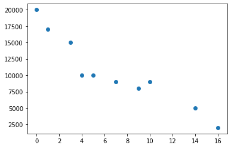

```python
import matplotlib.pyplot as plt

x=[1,0,3,5,14,7,4,16,9,10]
y=[17000,20000,15000,10000,5000,9000,10000,2000,8000,9000]

plt.scatter(x,y)
```

**Lab 12.3.1**

```python
from scipy import stats

x=[1,0,3,5,14,7,4,16,9,10]
y=[17000,20000,15000,10000,5000,9000,10000,2000,8000,9000]

stats.linregress(x,y)
```

```
LinregressResult(slope=-955.6247567146751, intercept=17093.81082133126, rvalue=-0.9382548923679298, pvalue=5.899842619735838e-05, stderr=124.57425008729852)
```

Interpretation: slope=-955.6247567146751, intercept=17093.81082133126, rvalue=-0.9382548923679298, pvalue=5.899842619735838e-05

**Lab 12.3.1 (Alternative Solution Using Array)**

```python
from scipy import stats

x=[1,0,3,5,14,7,4,16,9,10]
y=[17000,20000,15000,10000,5000,9000,10000,2000,8000,9000]

results = stats.linregress(x,y) # save results as an arry named results

print('slope =', results[0]) # results[0] is the slope
print('intercept =', results[1]) # results[1] is the intercept
print('r =', results[2]) # results[2] is the r correlation-coefficient
print('p-value =', results[3]) # results[3] is p-value for testing pop. cor. co
```

```
slope = -955.6247567146751
intercept = 17093.81082133126
r = -0.9382548923679298
p-value = 5.899842619735838e-05
```

Interpretation: slope=-955.6247567146751, intercept=17093.81082133126, rvalue=-0.9382548923679298, pvalue=5.899842619735838e-05

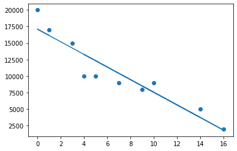

```python
import matplotlib.pyplot as plt
import numpy as np


x=[1,0,3,5,14,7,4,16,9,10]
y=[17000,20000,15000,10000,5000,9000,10000,2000,8000,9000]

x = np.array(x)
y = np.array(y)

y_hat = -955.6247567146751*x+17093.81082133126

plt.scatter(x,y)
plt.plot(x,y_hat)
```

**Lab 13.1.1**

```python
import numpy as np
from scipy import stats

obs = [306,232]
sum = np.sum(obs)
exp = [.513*sum,.469*sum]

stats.chisquare(obs,exp)
```

```
Power_divergenceResult(statistic=4.89897772395255, pvalue=0.026872598995409867)
```

Interpretation: Since the p-value 0.026872598995409867 is less than $\alpha=.10$, reject the null-hypothesis. There is enough evidence to reject the official's claim.

**Lab 13.2.1**

```python
def chi2_test_of_indp(obs):
    from scipy import stats
    chi2, p, dof, ex = stats.chi2_contingency(obs)

    print("chi-square test statitic:",chi2)
    print("p-value:", p)
```

```python
r1 = [1734,475,1281]
r2 = [2071,373,1938]
r3 = [678,103,935]
r4 = [534,92,560]
r5 = [5644,1661,2613]
r6 = [4094,927,1277]

obs = [r1,r2,r3,r4,r5,r6]

chi2_test_of_indp(obs)
```

```
chi-square test statitic: 1509.7409528009978
p-value: 0.0
```

Interpretation: Since the p-value=0.0 is less than the level of significance, reject the null hypothesis. That is, there is enough evidence that race and crime-class are NOT independent.

**Lab 14.1.1**

```python
import pandas as pd

x = ['male','female','female','male','male']
x_pd = pd.DataFrame({'gender':x})
print(x_pd)
```

```
   gender
0    male
1  female
2  female
3    male
4    male
```

**Lab 14.1.2**

```python
import pandas as pd
x=[20, 21, 25, 20, 29, 25, 22, 25, 21, 25]
x_df=pd.DataFrame({'data':x})
x_df.value_counts(sort=False)
```

```
data
20      2
21      2
22      1
25      4
29      1
dtype: int64
```

| data | freq |
| --- | --- |
| 20 | 2 |
| 21 | 2 |
| 22 | 1 |
| 25 | 4 |
| 29 | 1 |

**Lab 14.1.3**

```python
import pandas as pd
x=[20, 21, 25, 20, 29, 25, 22, 25, 21, 25]
x_df=pd.DataFrame({'data':x})
x_df.value_counts(sort=False,normalize=True)
```

```
data
20      0.2
21      0.2
22      0.1
25      0.4
29      0.1
dtype: float64
```

**Lab 14.1.4**

```python
import pandas as pd
x=['NO', 'NO', 'YES', 'YES', 'NO', 'YES', 'NO', 'NO', 'YES', 'NO', 'YES', 'NO',
   'NO', 'YES', 'YES', 'YES', 'YES', 'NO', 'YES', 'YES']

x_df = pd.DataFrame({'vote':x})
x_df.value_counts(normalize=True)
```

```
vote
YES     0.55
NO      0.45
dtype: float64
```

**Lab 14.1.5**

```python
import pandas as pd
x = [46776, 53736, 53736, 54840, 57408, 57408, 57408, 57408, 57408, 57408,
     60108, 60108, 62712, 63552, 66852, 66852, 69732, 70032, 70044, 70272,
     72024, 73380, 73380, 73380, 75408, 75468, 76248, 80484, 80484, 80484,
     82476, 82788, 82836, 83676, 84324, 84324, 84324, 85848, 87564, 88272,
     88272, 90828, 92004, 92304, 92520, 96060, 96096, 100680, 100716, 100716,
     103764, 105420, 109620, 146868]

x_df = pd.DataFrame({'data':x})

x_df.describe()
```

|  | data |
| --- | --- |
| count | 54.000000 |
| mean | 78460.000000 |
| std | 18253.562584 |
| min | 46776.000000 |
| 25% | 64377.000000 |
| 50% | 78366.000000 |
| 75% | 88272.000000 |
| max | 146868.000000 |

**Lab 14.1.6**

```python
import pandas as pd
x = [46776, 53736, 53736, 54840, 57408, 57408, 57408, 57408, 57408, 57408,
     60108, 60108, 62712, 63552, 66852, 66852, 69732, 70032, 70044, 70272,
     72024, 73380, 73380, 73380, 75408, 75468, 76248, 80484, 80484, 80484,
     82476, 82788, 82836, 83676, 84324, 84324, 84324, 85848, 87564, 88272,
     88272, 90828, 92004, 92304, 92520, 96060, 96096, 100680, 100716, 100716,
     103764, 105420, 109620, 146868]

x_df = pd.DataFrame({'salary':x})
print('skewness index is ',x_df.skew())
print('kurtosis index is',x_df.kurtosis())
```

```
skewness index is  salary    0.924462
dtype: float64
kurtosis index is salary    2.250167
dtype: float64
```

**Lab 14.2.1**

```python
import pandas as pd

url = 'https://raw.githubusercontent.com/swaathi/cleaning-datasets-using-pandas/master/data.csv'

x_df = pd.read_csv(url)

x_df.info()
```

```
<class 'pandas.core.frame.DataFrame'>
RangeIndex: 120 entries, 0 to 119
Data columns (total 14 columns):
 #   Column             Non-Null Count  Dtype
---  ------             --------------  -----
 0   valid_import       120 non-null    bool
 1   item               120 non-null    object
 2   importer_id        120 non-null    int64
 3   exporter_id        120 non-null    int64
 4   country_of_origin  120 non-null    object
 5   declared_quantity  120 non-null    int64
 6   declared_cost      120 non-null    float64
 7   mode_of_transport  120 non-null    object
 8   route              120 non-null    object
 9   date_of_departure  120 non-null    object
 10  date_of_arrival    120 non-null    object
 11  declared_weight    120 non-null    float64
 12  actual_weight      120 non-null    float64
 13  days_in_transit    120 non-null    float64
dtypes: bool(1), float64(4), int64(3), object(6)
memory usage: 12.4+ KB
```

Interpretation: for x_df

**Lab 14.3.1**

```python
import pandas as pd

url = 'https://raw.githubusercontent.com/swaathi/cleaning-datasets-using-pandas/master/data.csv'

x_df = pd.read_csv(url)

x_df.describe()
```

|  | importer_id | exporter_id | declared_quantity | declared_cost | declared_weight | actual_weight | days_in_transit |
| --- | --- | --- | --- | --- | --- | --- | --- |
| count | 120.0 | 120.0 | 120.000000 | 120.000000 | 120.000000 | 120.000000 | 120.000000 |
| mean | 111.0 | 222.0 | 127.458333 | 6743.649881 | 1264.702934 | 1306.429806 | 35.424705 |
| std | 0.0 | 0.0 | 14.641311 | 2991.797050 | 633.149971 | 656.911704 | 26.571591 |
| min | 111.0 | 222.0 | 100.000000 | 1441.012419 | 18.459509 | 19.275241 | 12.410325 |
| 25% | 111.0 | 222.0 | 115.750000 | 4442.903914 | 820.314400 | 841.763738 | 18.225625 |
| 50% | 111.0 | 222.0 | 131.500000 | 6010.218745 | 1255.597743 | 1305.716419 | 27.044293 |
| 75% | 111.0 | 222.0 | 139.000000 | 8887.095370 | 1711.314045 | 1763.681083 | 44.356374 |
| max | 111.0 | 222.0 | 149.000000 | 14281.325362 | 2806.338955 | 2918.681683 | 147.787560 |

Interpretatoin: The descriptive statistics for `importer_id` and `exporter_id` are meaningless and should be ignored.

**Lab 14.3.2**

```python
import pandas as pd

url = 'https://raw.githubusercontent.com/swaathi/cleaning-datasets-using-pandas/master/data.csv'

x_df = pd.read_csv(url)

x_df.groupby(['country_of_origin']).agg({'actual_weight':['mean','std','size']})
```

| country_of_origin | actual_weight mean | actual_weight std | actual_weight size |
| --- | --- | --- | --- |
| China | 1307.147246 | 627.380399 | 24 |
| France | 1218.459074 | 728.100019 | 24 |
| India | 1304.722531 | 493.478451 | 24 |
| Italy | 1190.657039 | 711.818853 | 24 |
| USA | 1511.163138 | 702.116897 | 24 |

**Lab 14.3.3**

```python
import pandas as pd

url = 'https://raw.githubusercontent.com/swaathi/cleaning-datasets-using-pandas/master/data.csv'

x_df = pd.read_csv(url)

x_df.groupby(['country_of_origin','route']).agg({'actual_weight':['mean','std','size']})
```

| country_of_origin | route | actual_weight mean | actual_weight std | actual_weight size |
| --- | --- | --- | --- | --- |
| China | america | 1281.081635 | 873.244407 | 6 |
|  | asia | 1492.969412 | 577.826149 | 6 |
|  | europe | 1155.582715 | 465.171493 | 6 |
|  | panama | 1298.955222 | 654.115536 | 6 |
| France | america | 1142.095755 | 686.692379 | 6 |
|  | asia | 1218.311778 | 936.931509 | 6 |
|  | europe | 1062.014711 | 756.490150 | 6 |
|  | panama | 1451.414052 | 644.548543 | 6 |
| India | america | 1007.777832 | 495.847993 | 6 |
|  | asia | 1697.493097 | 254.063822 | 6 |
|  | europe | 1379.484100 | 516.208468 | 6 |
|  | panama | 1134.135095 | 459.075799 | 6 |
| Italy | america | 1035.376749 | 923.534914 | 6 |
|  | asia | 1512.269050 | 974.452899 | 6 |
|  | europe | 1002.642317 | 461.640254 | 6 |
|  | panama | 1212.340040 | 345.152024 | 6 |
| USA | america | 1352.550563 | 895.589850 | 6 |
|  | asia | 1730.803390 | 725.189852 | 6 |
|  | europe | 1445.528489 | 666.483253 | 6 |
|  | panama | 1515.770109 | 634.190270 | 6 |

**Lab 14.3.4**

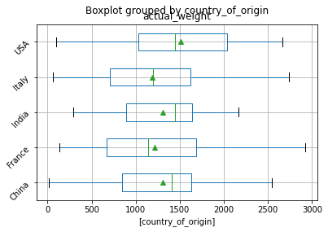

```python
import pandas as pd

url = 'https://raw.githubusercontent.com/swaathi/cleaning-datasets-using-pandas/master/data.csv'

x_df = pd.read_csv(url)

x_df.boxplot(column=['actual_weight'],by=['country_of_origin'],showmeans=True,vert=False,rot=45)
```

**Lab 14.3.4 Alternative Solution**

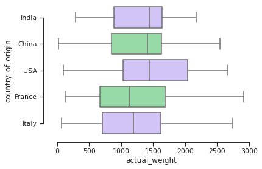

```python
import pandas as pd
import seaborn as sns
sns.set_theme(style="ticks", palette="pastel")

# Load the example tips dataset
url = 'https://raw.githubusercontent.com/swaathi/cleaning-datasets-using-pandas/master/data.csv'

x_df = pd.read_csv(url)

sns.boxplot(x="actual_weight", y="country_of_origin", hue_order="smoker", palette=["m", "g"], data=x_df)
sns.despine(offset=10, trim=True)
```

**Lab 14.4.1**

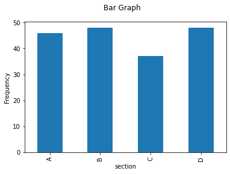

```python
import pandas as pd

url='https://raw.githubusercontent.com/simeonaman/demo/master/my_csv_file.csv'

x_df = pd.read_csv(url)
x_df.groupby(['section']).size().plot(kind='bar')

import matplotlib.pyplot as plt

plt.suptitle("Bar Graph")
plt.ylabel("Frequency")
```

**Lab 14.4.2**

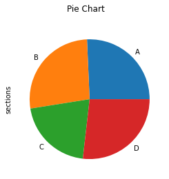

```python
import pandas as pd

url='https://raw.githubusercontent.com/simeonaman/demo/master/my_csv_file.csv'

x_df = pd.read_csv(url)
x_df.groupby(['section']).size().plot(kind='pie')

import matplotlib.pyplot as plt

plt.suptitle("Pie Chart")
plt.ylabel("sections")
```

**Lab 14.5.1**

```python
import pandas as pd

url = 'https://raw.githubusercontent.com/Shreyas3108/house-price-prediction/master/kc_house_data.csv'

x_df = pd.read_csv(url)
```

```python
import statsmodels.formula.api as smf
model = smf.ols(formula='price ~ bedrooms + sqft_basement + sqft_living', data=x_df)
results = model.fit()

print(results.summary())
```

```
                            OLS Regression Results
==============================================================================
Dep. Variable:                  price   R-squared:                       0.508
Model:                            OLS   Adj. R-squared:                  0.508
Method:                 Least Squares   F-statistic:                     7426.
Date:                Wed, 11 Aug 2021   Prob (F-statistic):               0.00
Time:                        13:38:08   Log-Likelihood:            -2.9995e+05
No. Observations:               21613   AIC:                         5.999e+05
Df Residuals:                   21609   BIC:                         5.999e+05
Df Model:                           3
Covariance Type:            nonrobust
=================================================================================
                    coef    std err          t      P>|t|      [0.025      0.975]
---------------------------------------------------------------------------------
Intercept      8.547e+04   6673.321     12.807      0.000    7.24e+04    9.85e+04
bedrooms      -5.806e+04   2312.155    -25.111      0.000   -6.26e+04   -5.35e+04
sqft_basement    26.6854      4.409      6.053      0.000      18.044      35.327
sqft_living     308.9346      2.478    124.668      0.000     304.077     313.792
==============================================================================
Omnibus:                    14369.246   Durbin-Watson:                   1.985
Prob(Omnibus):                  0.000   Jarque-Bera (JB):           489010.614
Skew:                           2.718   Prob(JB):                         0.00
Kurtosis:                      25.660   Cond. No.                     9.07e+03
==============================================================================

Warnings:
[1] Standard Errors assume that the covariance matrix of the errors is correctly specified.
[2] The condition number is large, 9.07e+03. This might indicate that there are
strong multicollinearity or other numerical problems.
```

**Lab 14.5.2**

```python
import pandas as pd
df = pd.read_csv('https://raw.githubusercontent.com/simeonaman/demo/master/heart.csv')
df.head()
```

|  | row.names | sbp | tobacco | ldl | adiposity | famhist | typea | obesity | alcohol | age | chd |
| --- | --- | --- | --- | --- | --- | --- | --- | --- | --- | --- | --- |
| 0 | 1 | 160 | 12.00 | 5.73 | 23.11 | Present | 49 | 25.30 | 97.20 | 52 | 1 |
| 1 | 2 | 144 | 0.01 | 4.41 | 28.61 | Absent | 55 | 28.87 | 2.06 | 63 | 1 |
| 2 | 3 | 118 | 0.08 | 3.48 | 32.28 | Present | 52 | 29.14 | 3.81 | 46 | 0 |
| 3 | 4 | 170 | 7.50 | 6.41 | 38.03 | Present | 51 | 31.99 | 24.26 | 58 | 1 |
| 4 | 5 | 134 | 13.60 | 3.50 | 27.78 | Present | 60 | 25.99 | 57.34 | 49 | 1 |

```python
import statsmodels.formula.api as smf
model = smf.logit(formula='chd ~ ldl + age + sbp', data=df)
results = model.fit()

print(results.summary())
```

```
Optimization terminated successfully.
         Current function value: 0.553757
         Iterations 6
                           Logit Regression Results
==============================================================================
Dep. Variable:                    chd   No. Observations:                  462
Model:                          Logit   Df Residuals:                      458
Method:                           MLE   Df Model:                            3
Date:                Wed, 11 Aug 2021   Pseudo R-squ.:                  0.1416
Time:                        14:09:16   Log-Likelihood:                -255.84
converged:                       True   LL-Null:                       -298.05
Covariance Type:            nonrobust   LLR p-value:                 3.427e-18
==============================================================================
                 coef    std err          z      P>|z|      [0.025      0.975]
------------------------------------------------------------------------------
Intercept     -4.7372      0.768     -6.170      0.000      -6.242      -3.233
ldl            0.1863      0.053      3.487      0.000       0.082       0.291
age            0.0559      0.009      6.036      0.000       0.038       0.074
sbp            0.0048      0.005      0.898      0.369      -0.006       0.015
==============================================================================
```

**Lab 14.6.1**

```python
import pandas as pd

url='https://raw.githubusercontent.com/simeonaman/demo/master/my_csv_file.csv'

x_df = pd.read_csv(url)
```

```python
x_df.groupby(['level']).agg({'test3_score': ['mean', 'std','size']})
```

| level | test3_score mean | test3_score std | test3_score size |
| --- | --- | --- | --- |
| high | 53.773333 | 3.184170 | 60 |
| low | 53.750000 | 2.329727 | 60 |
| medium | 53.831667 | 2.536546 | 60 |

```python
import statsmodels.api as sm
from statsmodels.formula.api import ols
model = ols('test3_score ~ C(level)',data = x_df).fit()
table = sm.stats.anova_lm(model,type=1) # type 2 for equal or non-equal sample sizes
print(table)
```

```
             df       sum_sq   mean_sq         F    PR(>F)
C(level)    2.0     0.212333  0.106167  0.014477  0.985629
Residual  177.0  1298.037167  7.333543       NaN       NaN
```

Interpretation: Since the p-value 0.985629 is not less than $\alpha$ = 0.10, we fail to reject the null hypothesis that the averages for all three levels are equal. That is, there is no significant difference between the averages of `test3_score` of the three levels.

**Lab 14.6.2**

```python
import pandas as pd

url='https://raw.githubusercontent.com/simeonaman/demo/master/my_csv_file.csv'

x_df = pd.read_csv(url)
```

```python
x_df.groupby(['level','gender']).agg({'test3_score': ['mean', 'std','size']})
```

| level | gender | test3_score mean | test3_score std | test3_score size |
| --- | --- | --- | --- | --- |
| high | female | 54.036000 | 3.487463 | 25 |
|  | male | 53.585714 | 2.986946 | 35 |
| low | female | 53.857576 | 2.521412 | 33 |
|  | male | 53.618519 | 2.111696 | 27 |
| medium | female | 53.604167 | 2.688863 | 24 |
|  | male | 53.983333 | 2.456769 | 36 |

```python
import statsmodels.api as sm
from statsmodels.formula.api import ols
model = ols('test3_score ~ C(level) + C(gender)',data = x_df).fit()
table = sm.stats.anova_lm(model,type=1) # type 2 for non-equal sample sizes
print(table)
```

```
              df       sum_sq   mean_sq         F    PR(>F)
C(level)     2.0     0.212333  0.106167  0.014401  0.985704
C(gender)    1.0     0.494704  0.494704  0.067102  0.795906
Residual   176.0  1297.542462  7.372400       NaN       NaN
```

**Lab 14.6.3**

```python
import pandas as pd

url='https://raw.githubusercontent.com/simeonaman/demo/master/my_csv_file.csv'

x_df = pd.read_csv(url)
x_df.head()
```

|  | id | gender | section | time | level | test1_score | test2_score | test3_score |
| --- | --- | --- | --- | --- | --- | --- | --- | --- |
| 0 | 1 | female | C | 17.3 | low | 65.4 | 84.3 | 51.9 |
| 1 | 2 | female | D | 5.1 | low | 72.4 | 86.1 | 52.0 |
| 2 | 3 | female | A | 2.4 | low | 73.8 | 84.2 | 53.1 |
| 3 | 4 | female | A | 8.8 | low | 70.2 | 87.9 | 52.0 |
| 4 | 5 | male | B | 15.0 | low | 60.3 | 81.4 | 55.5 |

```python
x_df.groupby(['level','section']).agg({'test3_score': ['mean', 'std','size']})
```

| level | section | test3_score mean | test3_score std | test3_score size |
| --- | --- | --- | --- | --- |
| high | A | 54.207143 | 3.816657 | 14 |
|  | B | 52.538462 | 2.417484 | 13 |
|  | C | 54.146667 | 3.044636 | 15 |
|  | D | 54.105882 | 3.362192 | 17 |
| low | A | 54.000000 | 1.942384 | 15 |
|  | B | 53.618750 | 1.880858 | 16 |
|  | C | 53.750000 | 2.469548 | 16 |
|  | D | 53.623077 | 3.181235 | 13 |
| medium | A | 53.982353 | 2.444441 | 17 |
|  | B | 53.126316 | 1.659264 | 19 |
|  | C | 53.250000 | 2.962938 | 6 |
|  | D | 54.627778 | 3.136841 | 18 |

```python
from statsmodels.formula.api import ols
model = ols('test3_score ~ C(level)*C(section)',data = x_df).fit()
table = sm.stats.anova_lm(model,type=2) # type 2 for non-equal sample sizes
print(table)
```

```
                        df       sum_sq    mean_sq         F    PR(>F)
C(level)               2.0     0.200742   0.100371  0.013460  0.986631
C(section)             3.0    31.217036  10.405679  1.395460  0.246013
C(level):C(section)    6.0    19.884361   3.314060  0.444434  0.848150
Residual             167.0  1245.286911   7.456808       NaN       NaN
```

# **References**

## Arithmetic Operators

| Name | Operator | Example | Result |
| --- | --- | --- | --- |
| Addition | `+` | `5+6` | `11` |
| Subtraction | `-` | 5-6 | `-1` |
| Multiplication | `*` | `5*6` | `30` |
| Division | `/` | `5/6` | `0.83333` |
| Exponentiation | `**` | `5**2` | $5^2$ =`25` |

## Descriptive Stats

```
import numpy as np
import pandas as pd

x=[x1,x2,x3,...]

x_df=pd.DataFrame({'column_name':x})
```

| procedure | numpy | pandas |
| --- | --- | --- |
| frequency counts | `np.unique(x,return_counts=True)` | `x_df.value_counts()` |
| size | `np.size(x)` | `x_df.count()` |
| min | `np.amin(x)` | `x_df.min()` |
| max | `np.amax(x)` | `x_df.max()` |
| mean | `np.mean(x)` | `x_df.mean()` |
| mode | NA | `x_df.mode()` |
| median | `np.median(x)` | `x_df.median()` |
| sample variance | `np.var(x,ddf=1)` | `x_df.var()` |
| pop variance | `np.var(x)` | `x_df.var(ddof=0)` |
| sample std | `np.std(x,ddof=1)` | `x_df.std()` |
| pop std | `np.std(x)` | `x_df.std(ddof=0)` |
| weighted mean | `np.average(x,weights=freq)` | NA |
| weighted sample std | `(np.cov(x,fweights=freq,dd0f=1))**(1/2)` | NA |
| weighted pop std | `(np.cov(x,fweights=freq))**(1/2)` | NA |
| percentiles | `np.quantile(x,p)` | `x_df.quantile(p)` |
| summary stats | NA | `x_df.describe()` |
| factorial, n! | `np.math.factorial(n)` | NA |
| n random integers from a to b | `np.random.randint(a,b+1,size=n)` | NA |
| weighted mean | `np.average(x,weights=y)` | NA |
| Weighted std | `(np.cov(x,aweights=y,ddof=0)**(1/2)` | NA |
| correlation coef. | `np.corrcoef(x,y)` | `x_df.corr()` |

NA = Not Available

Summary statistics by grouping with categorical columns:

`x_df.groupby(['level','gender']).agg({'test1_score': ['mean','std','size']})`

## Graphs

```
import pandas as pd
import mathplotlib.pyplot as plt

x = [x1, x2, x3, ...]
x_df = pd.DataFrame({'column_name',x})

CHOOSE A CODE FROM BELOW (Bar, Pie, Histogram etc)

plt.suptitle("Plot Title")
plt.xlabel("x-axis label")
plt.ylabel("y-axis label")
```

1. Bar graph (raw data) `x_df.groupby(['column_name']).size().plot(kind='bar')`
2. Pie Chart (raw data) `x_df.groupby(['column_name']).size().plot(kind='pie', autopct='%1.1f%%')`
3. Bar graph (frequency table) `x_df.plot.bar(x='column_name',y='frequency')`
4. Pie chart (frequency table)

```
x_df.set_index('column_name',inplace=True)
x_df.plot.pie(y='frequency')
```

5. Side by Side Bar (frequency table)

```
x_df.set_index('column_name',inplace=True)
x_df.plot.bar()
```

6. Histogram

```
freq,bins,patches = plt.hist(x,bins=5,ec='k',range=[min(x),max(x)+1])
plt.xticks(bins)   # df['column_name']=x
```

7. Scater Plot (x, y list given) `plt.scatter(x,y)`

## Linear Regression

```
from scipy import stats
stats.linregress(x_list, y_list)
```

## Multiple Linear Regression

```
import statsmodels.formula.api as smf
model = smf.ols(formula='y ~ x1 + x2 +...+ xk', data=x_df)
results = model.fit()

print(results.summary())
```

## Probability Distributions

```
from scipy import stats
```

| procedure | scipy.stats |
| --- | --- |
| Binomial pdf $P(X=x)$ | `stats.binom.pmf(x,n,p)` |
| Binomial cdf $P(X\le x)$ | `stats.binom.cdf(x,n,p)` |
| Normal cdf $P(X\le x)$ | `stats.norm.cdf(x,mean,std)` |
| Inverse Normal or p-th Percentile | `stats.norm.ppf(p,mean,std)` |
| *t* distribution cdf $P(X\le x)$ | `stats.t.cdf(t,df,0,1)` |
| Inverse *t* or p-th Percentile | `stats.t.ppf(p,df,0,1)` |
| chi-square cdf $P(\chi^2 \le ch2)$ | `stats.chi2.cdf(ch2,k-1)` |
| Inverse chi-square or p-th Percentile | `stats.chi2.ppf(p,k-1)` |

## Margin of Error for Confidence Interval

```
from scipy import stats
```

Mean $\mu$ with $z$ distribution with confidence level `C`, (population) standard deviation `std` and sample size `n`:

```
E = (std/n**.5)*stats.norm.ppf(C+(1-C)/2,0,1)
```

Mean $\mu$ with $t$ distribution with confidence level `C`, sample standard deviation `std` and sample size `n`:

```
E = (std/n**.5)*stats.t.ppf(C+(1-C)/2,0,1)
```

Proportion $p$ with $z$ distribution with confidence level `C`, sample proportion `p` and sample size `n`:

```
E = (p(p*(1-p)/n)**.5)*stats.norm.ppf(C+(1-C)/2,0,1)
```

# **Appendix 1**

**Python Computer Installation**

If you prefer not to use Google Colab Notebook, you can install free Python in your computer and use the **Anaconda Jupyter Notebook**. Go to [this website](https://www.anaconda.com/products/individual#Downloads) and select Windows, MacOS or Linux, depending on your computer. When the installation is completed, open **jupyter Notebook(anaconda3)** from the **Anaconda** folder on your computer. You can also watch YouTube videos on how to install Anaconda for [Windows 10](https://youtu.be/g6ln1dAt-RI) or [MacOS](https://youtu.be/V6ZAv7hBH6Y).

Open **Jupyter Notebook** from your Windows computer Start menu under **Anaconda** and click **new**. You can add new code-cell or text-cell by clicking + and code (see pictures below). You can run a code-cell by clicking **run**.

[figure not shown]

[figure not shown]

# **Appendix 2: Random Integer Generator**

[Watch demo video](https://watch.screencastify.com/v/KIDjEiCx10j6cnhERP12)

# **Appendix 3: Factorials**

[Watch demo video](https://watch.screencastify.com/v/DBZauBKSZpeyS1O5WFw2)

# **Resources**

- [Python.org](https://www.python.org/)
- [Matplotlib](https://matplotlib.org/stable/api/_as_gen/matplotlib.pyplot.boxplot.html)
- [Python eBook](https://greenteapress.com/thinkpython/html/index.html)
- [Introductory Statistics eBook](https://openstax.org/books/introductory-statistics/pages/1-introduction)
- [Python Tutorials](https://www.w3schools.com/python/default.asp)
- [Terminology](https://www.computerhope.com/jargon/program.htm#i)
- [Numpy](https://numpy.org/doc/stable/user/absolute_beginners.html)
- [Scipy Stats](https://docs.scipy.org/doc/scipy/reference/stats.html#) -[Pandas](https://pandas.pydata.org/docs/getting_started/intro_tutorials/index.html)